# Starbucks Capstone Challenge

### Introduction

This data set contains simulated data that mimics customer behavior on the Starbucks rewards mobile app. Once every few days, Starbucks sends out an offer to users of the mobile app. An offer can be merely an advertisement for a drink or an actual offer such as a discount or BOGO (buy one get one free). Some users might not receive any offer during certain weeks.

Not all users receive the same offer, and that is the challenge to solve with this data set.

Your task is to combine transaction, demographic and offer data to determine which demographic groups respond best to which offer type. This data set is a simplified version of the real Starbucks app because the underlying simulator only has one product whereas Starbucks actually sells dozens of products.

Every offer has a validity period before the offer expires. As an example, a BOGO offer might be valid for only 5 days. You'll see in the data set that informational offers have a validity period even though these ads are merely providing information about a product; for example, if an informational offer has 7 days of validity, you can assume the customer is feeling the influence of the offer for 7 days after receiving the advertisement.

You'll be given transactional data showing user purchases made on the app including the timestamp of purchase and the amount of money spent on a purchase. This transactional data also has a record for each offer that a user receives as well as a record for when a user actually views the offer. There are also records for when a user completes an offer.

Keep in mind as well that someone using the app might make a purchase through the app without having received an offer or seen an offer.

### Example

To give an example, a user could receive a discount offer buy 10 dollars get 2 off on Monday. The offer is valid for 10 days from receipt. If the customer accumulates at least 10 dollars in purchases during the validity period, the customer completes the offer.

However, there are a few things to watch out for in this data set. Customers do not opt into the offers that they receive; in other words, a user can receive an offer, never actually view the offer, and still complete the offer. For example, a user might receive the "buy 10 dollars get 2 dollars off offer", but the user never opens the offer during the 10 day validity period. The customer spends 15 dollars during those ten days. There will be an offer completion record in the data set; however, the customer was not influenced by the offer because the customer never viewed the offer.

### Cleaning

This makes data cleaning especially important and tricky.

You'll also want to take into account that some demographic groups will make purchases even if they don't receive an offer. From a business perspective, if a customer is going to make a 10 dollar purchase without an offer anyway, you wouldn't want to send a buy 10 dollars get 2 dollars off offer. You'll want to try to assess what a certain demographic group will buy when not receiving any offers.

### Final Advice

Because this is a capstone project, you are free to analyze the data any way you see fit. For example, you could build a machine learning model that predicts how much someone will spend based on demographics and offer type. Or you could build a model that predicts whether or not someone will respond to an offer. Or, you don't need to build a machine learning model at all. You could develop a set of heuristics that determine what offer you should send to each customer (i.e., 75 percent of women customers who were 35 years old responded to offer A vs 40 percent from the same demographic to offer B, so send offer A).

# Data Sets

The data is contained in three files:

- portfolio.json - containing offer ids and meta data about each offer (duration, type, etc.)
- profile.json - demographic data for each customer
- transcript.json - records for transactions, offers received, offers viewed, and offers completed

Here is the schema and explanation of each variable in the files:

**portfolio.json**

- id (string) - offer id
- offer_type (string) - type of offer ie BOGO, discount, informational
- difficulty (int) - minimum required spend to complete an offer
- reward (int) - reward given for completing an offer
- duration (int) - time for offer to be open, in days
- channels (list of strings)

**profile.json**

- age (int) - age of the customer
- became_member_on (int) - date when customer created an app account
- gender (str) - gender of the customer (note some entries contain 'O' for other rather than M or F)
- id (str) - customer id
- income (float) - customer's income

**transcript.json**

- event (str) - record description (ie transaction, offer received, offer viewed, etc.)
- person (str) - customer id
- time (int) - time in hours since start of test. The data begins at time t=0
- value - (dict of strings) - either an offer id or transaction amount depending on the record

```python
#HDBSCAN (Horizontal Density-Based Spatial Clustering of Applications with Noise)
!pip install hdbscan
#Apache MxNet
!pip install mxnet
```

```
  Using cached hdbscan-0.8.27.tar.gz (6.4 MB)
  Installing build dependencies ... done
  Getting requirements to build wheel ... done
  Preparing metadata (pyproject.toml) ... done
     |████████████████████████████████| 47.3 MB 18.7 MB/s
```

```python
#Import required packages

#General Packages
import math
import json
import os
import datetime
import mxnet as mx

#AWS
import boto3
import sagemaker
from sagemaker import get_execution_role
from sagemaker import PCA


#Data Analysis and Visualization Packages
import pandas as pd
import numpy as np
import matplotlib.pyplot as plt
import seaborn as sns
from tqdm import tqdm # For progress meter (Optional)

#HDBSCAN
import hdbscan

#Sklearn Packages
import sklearn
import sklearn.metrics as metrics
from sklearn.metrics import silhouette_score
from sklearn.preprocessing import MultiLabelBinarizer, StandardScaler
from sklearn.impute import SimpleImputer
from sklearn.cluster import KMeans, MiniBatchKMeans
from sklearn.decomposition import PCA
from sklearn.manifold import TSNE
from sklearn.cluster import DBSCAN
from sklearn.neighbors import NearestNeighbors

#Magic Function
%matplotlib inline
```

```python
# Defining data file locations
bucket='capstone-data-files'
profile_data_location = 's3://{}/{}'.format(bucket, 'profile.json')
portfolio_data_location = 's3://{}/{}'.format(bucket, 'portfolio.json')
transcript_data_location = 's3://{}/{}'.format(bucket, 'transcript.json')
```

```python
# Read in the input data files
portfolio = pd.read_json(portfolio_data_location, orient='records', lines=True)
profile = pd.read_json(profile_data_location, orient='records', lines=True)
transcript = pd.read_json(transcript_data_location, orient='records', lines=True)
```

```python
# Adding an attribute 'name' for each dataset
portfolio.name = "Portfolio"
profile.name = "Profile"
transcript.name = "Transcript"
```

# Data Exploration

```python
def quickDescribe(df):
  '''
    Function:
      The features and calculated statistics relevant to the problem have been reported and discussed,
      along with a sampling of the data.
    Input:
      A dataframe containing the input data
    Output:
      Name, Sample, Shape, Features, Description, Null Values if any, and, Pairplot of the DataFrame.
  '''
  print("Name:",df.name,"\n")
  print("First Five Rows:")
  display(df.head())
  print("\nShape of DataFrame:",df.shape,"\n")
  print("Features :", df.columns.tolist(),"\n")
  print("Description of DataFrame:\n",df.describe(),"\n")
  print("Number of null values:\n",df.isnull().sum(),"\n")
  print("Plot:\n",sns.pairplot(df),"\n")
```

```
Name: Portfolio

First Five Rows:
```

|  | reward | channels | difficulty | duration | offer_type | id |
| --- | --- | --- | --- | --- | --- | --- |
| 0 | 10 | [email, mobile, social] | 10 | 7 | bogo | ae264e3637204a6fb9bb56bc8210ddfd |
| 1 | 10 | [web, email, mobile, social] | 10 | 5 | bogo | 4d5c57ea9a6940dd891ad53e9dbe8da0 |
| 2 | 0 | [web, email, mobile] | 0 | 4 | informational | 3f207df678b143eea3cee63160fa8bed |
| 3 | 5 | [web, email, mobile] | 5 | 7 | bogo | 9b98b8c7a33c4b65b9aebfe6a799e6d9 |
| 4 | 5 | [web, email] | 20 | 10 | discount | 0b1e1539f2cc45b7b9fa7c272da2e1d7 |

```
Shape of DataFrame: (10, 6)

Features : ['reward', 'channels', 'difficulty', 'duration', 'offer_type', 'id']

Description of DataFrame:
           reward  difficulty   duration
count  10.000000   10.000000  10.000000
mean    4.200000    7.700000   6.500000
std     3.583915    5.831905   2.321398
min     0.000000    0.000000   3.000000
25%     2.000000    5.000000   5.000000
50%     4.000000    8.500000   7.000000
75%     5.000000   10.000000   7.000000
max    10.000000   20.000000  10.000000

Number of null values:
 reward        0
channels      0
difficulty    0
duration      0
offer_type    0
id            0
dtype: int64

Plot:
```

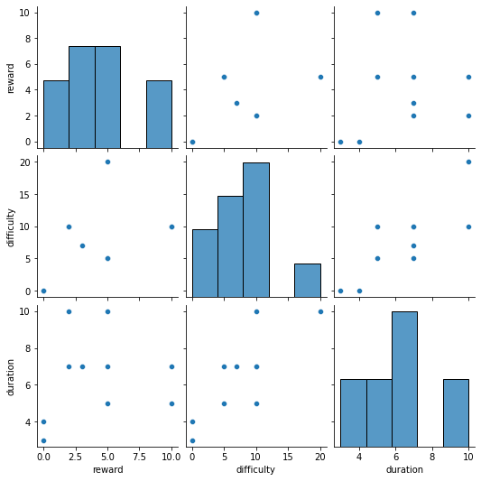

```python
quickDescribe(portfolio)
```

```
Name: Profile

First Five Rows:
```

|  | gender | age | id | became_member_on | income |
| --- | --- | --- | --- | --- | --- |
| 0 | None | 118 | 68be06ca386d4c31939f3a4f0e3dd783 | 20170212 | NaN |
| 1 | F | 55 | 0610b486422d4921ae7d2bf64640c50b | 20170715 | 112000.0 |
| 2 | None | 118 | 38fe809add3b4fcf9315a9694bb96ff5 | 20180712 | NaN |
| 3 | F | 75 | 78afa995795e4d85b5d9ceeca43f5fef | 20170509 | 100000.0 |
| 4 | None | 118 | a03223e636434f42ac4c3df47e8bac43 | 20170804 | NaN |

```
Shape of DataFrame: (17000, 5)

Features : ['gender', 'age', 'id', 'became_member_on', 'income']

Description of DataFrame:
                 age  became_member_on         income
count  17000.000000      1.700000e+04   14825.000000
mean      62.531412      2.016703e+07   65404.991568
std       26.738580      1.167750e+04   21598.299410
min       18.000000      2.013073e+07   30000.000000
25%       45.000000      2.016053e+07   49000.000000
50%       58.000000      2.017080e+07   64000.000000
75%       73.000000      2.017123e+07   80000.000000
max      118.000000      2.018073e+07  120000.000000

Number of null values:
 gender              2175
age                    0
id                     0
became_member_on       0
income              2175
dtype: int64

Plot:
```

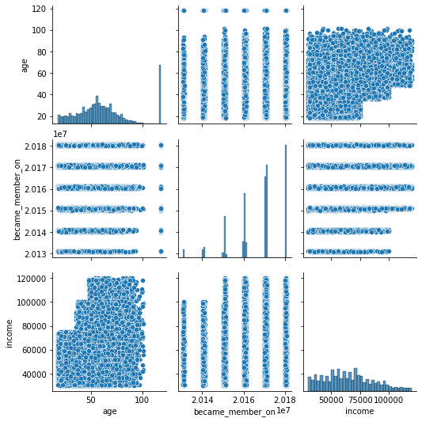

```python
quickDescribe(profile)
```

```
Name: Transcript

First Five Rows:
```

|  | person | event | value | time |
| --- | --- | --- | --- | --- |
| 0 | 78afa995795e4d85b5d9ceeca43f5fef | offer received | {'offer id': '9b98b8c7a33c4b65b9aebfe6a799e6d9'} | 0 |
| 1 | a03223e636434f42ac4c3df47e8bac43 | offer received | {'offer id': '0b1e1539f2cc45b7b9fa7c272da2e1d7'} | 0 |
| 2 | e2127556f4f64592b11af22de27a7932 | offer received | {'offer id': '2906b810c7d4411798c6938adc9daaa5'} | 0 |
| 3 | 8ec6ce2a7e7949b1bf142def7d0e0586 | offer received | {'offer id': 'fafdcd668e3743c1bb461111dcafc2a4'} | 0 |
| 4 | 68617ca6246f4fbc85e91a2a49552598 | offer received | {'offer id': '4d5c57ea9a6940dd891ad53e9dbe8da0'} | 0 |

```
Shape of DataFrame: (306534, 4)

Features : ['person', 'event', 'value', 'time']

Description of DataFrame:
                 time
count  306534.000000
mean      366.382940
std       200.326314
min         0.000000
25%       186.000000
50%       408.000000
75%       528.000000
max       714.000000

Number of null values:
 person    0
event     0
value     0
time      0
dtype: int64

Plot:
```

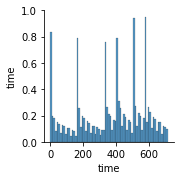

```python
quickDescribe(transcript)
```

## Cleaning Profile Dataframe

```python
def clean_profile(profile):
    # Dropping rows with null information
    profile.dropna(inplace = True)

    # Renaming 'id' column to 'customer_id'
    profile.rename(columns = {'id': 'customer_id'}, inplace = True)
    # Converting 'became_member_on' column datatype to DateTime
    profile['became_member_on'] = profile['became_member_on'].apply(lambda x: datetime.datetime.strptime(str(x), '%Y%m%d').date())

    # Creating a new column named 'days_as_member' with the latest date as 26th July 2018
    most_recent_date = profile['became_member_on'].max()
    end_date = pd.to_datetime(most_recent_date)
    profile['days_as_member'] = np.abs((pd.to_datetime(profile['became_member_on']) - end_date).dt.days)

    # Creating a new column named 'age_range' which consists of the age range that customer belongs to
    # The first age range is 18/19 and consists of only 18 and 19 year olds
    # NOTE: This column is only for easy visualization, feel free to skip this step
    age_labels = ['18/19', '20-29', '30-39', '40-49', '50-59', '60-69', '70-79', '80+']
    age_bins = [18, 20, 30, 40, 50, 60, 70, 80, 110]
    profile['age_range'] = pd.cut(profile['age'], bins=age_bins, labels=age_labels)
    profile['age_range'] = pd.Categorical(profile['age_range'], ordered = True, categories = age_labels)

    print("Profile Cleaning Done!\n")
    return profile
```

```python
profile = clean_profile(profile)
profile.head()
```

```
Profile Cleaning Done!
```

|  | gender | age | customer_id | became_member_on | income | days_as_member | age_range |
| --- | --- | --- | --- | --- | --- | --- | --- |
| 1 | F | 55 | 0610b486422d4921ae7d2bf64640c50b | 2017-07-15 | 112000.0 | 376 | 50-59 |
| 3 | F | 75 | 78afa995795e4d85b5d9ceeca43f5fef | 2017-05-09 | 100000.0 | 443 | 70-79 |
| 5 | M | 68 | e2127556f4f64592b11af22de27a7932 | 2018-04-26 | 70000.0 | 91 | 60-69 |
| 8 | M | 65 | 389bc3fa690240e798340f5a15918d5c | 2018-02-09 | 53000.0 | 167 | 60-69 |
| 12 | M | 58 | 2eeac8d8feae4a8cad5a6af0499a211d | 2017-11-11 | 51000.0 | 257 | 50-59 |

# Cleaning Portfolio Dataframe

- Renaming column names for better understanding
- One hot encode 'channels' and 'offer_type' columns
- Drop the above columns after encoding

### The encoding is done to ensure the data is able to fit well into our clustering model

```python
def clean_portfolio(portfolio):
    # Renaming the column appropriately
    portfolio.rename(columns = {'id': 'offer_id'}, inplace = True)

    # One hot encoding 'offer' column into 'offer_bogo', 'offer_discount', and 'offer_informational'
    dummy_offers = pd.get_dummies(portfolio['offer_type'], prefix = 'offer')
    portfolio = pd.concat([portfolio, dummy_offers], axis = 1)

    # One hot encoding 'channels' column into 'channel_email', 'channel_mobile', 'channel_social', and 'channel_web'
    channels_encode = MultiLabelBinarizer()
    separate_channels = channels_encode.fit_transform(portfolio['channels'])
    channels_diff = pd.DataFrame(data = separate_channels, columns = channels_encode.classes_)
    portfolio = pd.concat([portfolio, channels_diff], axis = 1)
    portfolio.rename(columns = {'email': 'channel_email', 'mobile': 'channel_mobile', 'social': 'channel_social', 'web': 'channel_web'}, inplace = True)

    # Dropping the previous 'channels' and 'offer_type' columns as they are encoded now
    portfolio.drop(columns = ['channels', 'offer_type'], axis = 1, inplace = True)

    print("Portfolio Cleaning Done!\n")

    return portfolio
```

```python
portfolio = clean_portfolio(portfolio)
portfolio.head()
```

```
Portfolio Cleaning Done!
```

|  | reward | difficulty | duration | offer_id | offer_bogo | offer_discount | offer_informational | channel_email | channel_mobile | channel_social | channel_web |
| --- | --- | --- | --- | --- | --- | --- | --- | --- | --- | --- | --- |
| 0 | 10 | 10 | 7 | ae264e3637204a6fb9bb56bc8210ddfd | 1 | 0 | 0 | 1 | 1 | 1 | 0 |
| 1 | 10 | 10 | 5 | 4d5c57ea9a6940dd891ad53e9dbe8da0 | 1 | 0 | 0 | 1 | 1 | 1 | 1 |
| 2 | 0 | 0 | 4 | 3f207df678b143eea3cee63160fa8bed | 0 | 0 | 1 | 1 | 1 | 0 | 1 |
| 3 | 5 | 5 | 7 | 9b98b8c7a33c4b65b9aebfe6a799e6d9 | 1 | 0 | 0 | 1 | 1 | 0 | 1 |
| 4 | 5 | 20 | 10 | 0b1e1539f2cc45b7b9fa7c272da2e1d7 | 0 | 1 | 0 | 1 | 0 | 0 | 1 |

# Cleaning Transcript Dataframe

- Renaming column names for better understanding
- Remove the customers that are not present in the profile file
- One hot encode 'event' column
- Convert 'time' column to 'days' along with appropriate values
- Separate the key:value pairs in the 'value' column into two different columns 'transcript_amount' and 'transcript_offer_id'

```python
def clean_transcript(transcript):
    # Changing the name of the 'person' column to 'customer_id'
    transcript.rename(columns = {'person': 'customer_id'}, inplace = True)

    # Inner joining 'profile' and 'transcript' dataframes based on column 'customer_id'
    transcript = pd.merge(left = transcript, right = profile, how = 'inner', left_on = 'customer_id', right_on = 'customer_id')
    transcript.drop(columns = ['age', 'became_member_on', 'gender', 'income', 'days_as_member', 'age_range'], inplace = True)

    # One hot encoding 'event' column into 'offer_completed', 'offer_received', and 'offer_viewed'
    dummy_event = pd.get_dummies(transcript['event'])
    dummy_event.rename(columns = {'offer completed': 'offer_completed', 'offer received': 'offer_received', 'offer viewed': 'offer_viewed'}, inplace = True)
    transcript = pd.concat([transcript, dummy_event], axis = 1)

    # Converting the 'time' column into 'days' column
    transcript['days'] = transcript['time'] / 24
    transcript.drop(columns = ['time'], inplace = True)

    '''
    Notice the value column, it contains a python dictionary of key:value pairs. For the dataframe to be fit into the model,
    these values must be separated into their own columns according to their keys
    '''

    #Initial separation
    transcript['offer-or-amount'] = transcript['value'].apply(lambda x: list(x.keys())[0])
    transcript['id-or-amount'] = transcript['value'].apply(lambda x: list(x.values())[0])

    #Changing all 'offer id' to 'offer_id' for consistency
    offer_dict = {'offer id': 'offer_id'}
    transcript['offer-or-amount'].replace(offer_dict, inplace = True)

    #Creating the transcript_offer DataFrame where the key is 'offer_id'
    transcript_offer = transcript[transcript['offer-or-amount'] == 'offer_id'].copy()
    transcript_offer.rename(columns = {'id-or-amount': 'offer_id'}, inplace = True)
    transcript_offer.drop(columns = ['event', 'value', 'offer-or-amount', 'transaction'], inplace = True)

    #Creating the transcript_amount DataFrame where the key is 'amount'
    transcript_amount = transcript[transcript['offer-or-amount'] == 'amount'].copy()
    transcript_amount.rename(columns = {'id-or-amount': 'amount'}, inplace = True)
    transcript_amount.drop(columns = ['event', 'value', 'offer-or-amount', 'offer_completed', 'offer_received', 'offer_viewed'], inplace = True)

    print("Transcript Cleaning Done!\n")

    return transcript_offer, transcript_amount
```

```python
transcript_offer, transcript_amount = clean_transcript(transcript)
transcript_offer.head()
```

```
Transcript Cleaning Done!
```

|  | customer_id | offer_completed | offer_received | offer_viewed | days | offer_id |
| --- | --- | --- | --- | --- | --- | --- |
| 0 | 78afa995795e4d85b5d9ceeca43f5fef | 0 | 1 | 0 | 0.00 | 9b98b8c7a33c4b65b9aebfe6a799e6d9 |
| 1 | 78afa995795e4d85b5d9ceeca43f5fef | 0 | 0 | 1 | 0.25 | 9b98b8c7a33c4b65b9aebfe6a799e6d9 |
| 3 | 78afa995795e4d85b5d9ceeca43f5fef | 1 | 0 | 0 | 5.50 | 9b98b8c7a33c4b65b9aebfe6a799e6d9 |
| 5 | 78afa995795e4d85b5d9ceeca43f5fef | 0 | 1 | 0 | 7.00 | 5a8bc65990b245e5a138643cd4eb9837 |
| 6 | 78afa995795e4d85b5d9ceeca43f5fef | 0 | 0 | 1 | 9.00 | 5a8bc65990b245e5a138643cd4eb9837 |

```python
transcript_amount.head()
```

|  | customer_id | transaction | days | amount |
| --- | --- | --- | --- | --- |
| 2 | 78afa995795e4d85b5d9ceeca43f5fef | 1 | 5.50 | 19.89 |
| 4 | 78afa995795e4d85b5d9ceeca43f5fef | 1 | 6.00 | 17.78 |
| 7 | 78afa995795e4d85b5d9ceeca43f5fef | 1 | 9.25 | 19.67 |
| 8 | 78afa995795e4d85b5d9ceeca43f5fef | 1 | 10.00 | 29.72 |
| 9 | 78afa995795e4d85b5d9ceeca43f5fef | 1 | 15.75 | 23.93 |

# Exploratory Visualization

Now that all the data has been cleaned and preprocessed, various visualizations have been provided that summarizes or extracts a relevant characteristic or feature about the dataset or input data.

```python
# Setting the palette to green to go with the theme of starbucks
palette = sns.color_palette("Greens",10)
```

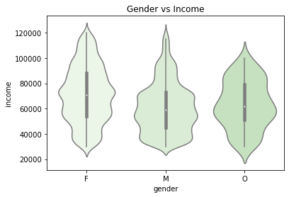

```python
ax = sns.violinplot(x="gender", y="income", data=profile,palette=palette)
ax.set_title("Gender vs Income");
```

The white dot represents the median, the thick black bar represents the interquartile range and the thin black bar represents the 1.5 interquartile range. The wider, thicker areas of the violin plot indicate higher probability/quantity. Therefore, here we can interpret, for example, more number of males have an income between 40000 and 80000, than 80000 and 120000.

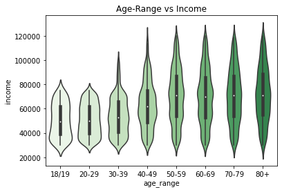

```python
ax = sns.violinplot(x="age_range", y="income", data=profile,palette=palette)
ax.set_title("Age-Range vs Income");
```

We can interpret here that, people in the age-range 18 to 30 mostly get an income of 80000 or less. Whereas >50 age-range reach a high of 120000.

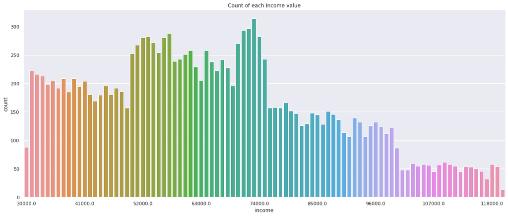

```python
ax = sns.countplot(x="income",data=profile)
sns.set(rc = {'figure.figsize':(20,8)})
ax.set_title("Count of each Income value");
'''
To prevent the x-axis labels from appearing cluttered or overlapped
I am displaying only one label for every 8.
Thanks to: https://stackoverflow.com/a/55585096
'''
ticks = ax.get_xticks()
labels = ax.get_xticklabels()
n = len(ticks) // 8
ax.set_xticks(ticks[::n]);
ax.set_xticklabels(labels[::n]);
```

Here, we can see that maximum number of people have an income of 52000 - 74000.

A fair number of people have from 30000 - 52000

And very few have greater than 100000.

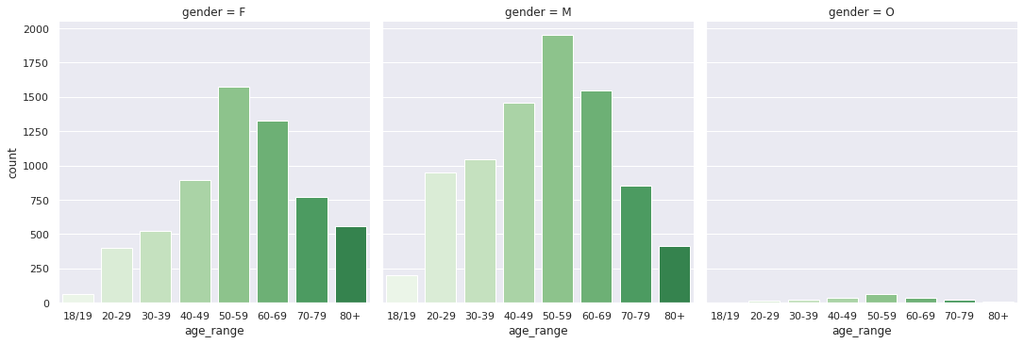

```python
ax = sns.catplot(x="age_range", kind="count", data=profile, col="gender",palette=palette)
```

Comparison of the count of different age-ranges for every gender. We can interpret, the app is used by mostly middle aged people (40-60).

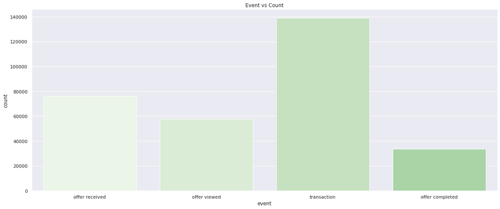

```python
ax = sns.countplot(x="event",data=transcript, palette = palette).set(title='Event vs Count')
```

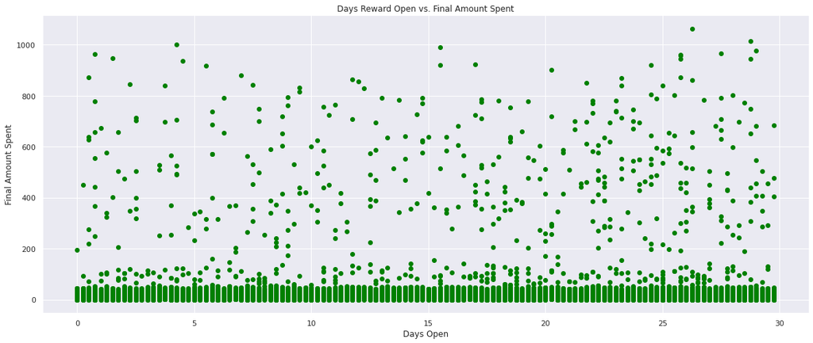

```python
#Visualizing the days open vs amount spent in a scatter plot
plt.scatter(data = transcript_amount, x = 'days', y = 'amount',c='green');
plt.title('Days Reward Open vs. Final Amount Spent');
plt.xlabel('Days Open');
plt.ylabel('Final Amount Spent');
plt.style.use('seaborn');
```

This is pretty much an evenly distributed chart, but the 'final amount spent' does seem to be more cluttered after the 'days open' exceeds 15

# Processing

- Merge all the data from our previous (portfolio, profile, transcript_amount, and transcript_offer) dataframes all into one main dataframe called customer_transactions.

```python
# Create a list of 'offer_bogo' offer ids and 'offer_discount' offer ids
bogo_list = portfolio.loc[portfolio['offer_bogo'] == 1, 'offer_id'].values.tolist()
print(bogo_list)
discount_list = portfolio.loc[portfolio['offer_discount'] == 1, 'offer_id'].values.tolist()
print(discount_list)
```

```
['ae264e3637204a6fb9bb56bc8210ddfd', '4d5c57ea9a6940dd891ad53e9dbe8da0', '9b98b8c7a33c4b65b9aebfe6a799e6d9', 'f19421c1d4aa40978ebb69ca19b0e20d']
['0b1e1539f2cc45b7b9fa7c272da2e1d7', '2298d6c36e964ae4a3e7e9706d1fb8c2', 'fafdcd668e3743c1bb461111dcafc2a4', '2906b810c7d4411798c6938adc9daaa5']
```

```python
'''
Function:
  To combine all the datasets together
Inputs:
  customer_ids: Array of customer ids
  portfolio: Portfolio DataFrame
  profile: Profile DataFrame
  transcript_amount: Transcript Amount DataFrame
  transcript_offer: Transcript Offer DataFrame
Returns:
  customer_transactions: DataFrame containing all the data from the input DataFrame in an organized manner
'''

def generate_main(customer_ids,portfolio=portfolio,profile=profile,transcript_amount=transcript_amount,transcript_offer=transcript_offer):
  customer_entries = [] # Creating a list for containing all the customer entries
  for customer_id in customer_ids:

    ''' Iterating through each customer id and extracting their attributes '''

    customer_attributes = profile[profile['customer_id'] == customer_id]
    age = customer_attributes['age'].values[0]
    became_member_on = customer_attributes['became_member_on'].values[0]
    gender = customer_attributes['gender'].values[0]
    income = customer_attributes['income'].values[0]
    days_as_member = customer_attributes['days_as_member'].values[0]
    age_range = customer_attributes['age_range'].values[0]

    # Initializing variables for later use

    num_discounts = 0
    num_bogos = 0
    percent_completed = 0
    bogo_percent_completed = 0
    discount_percent_completed = 0

    '''
    Calculating sum of 'offers', 'amount_spent', and 'transactions' as well as
    the mean of the 'amount_spent'
    '''

    total_viewed = transcript_offer[transcript_offer['customer_id'] == customer_id]['offer_viewed'].sum()
    total_received = transcript_offer[transcript_offer['customer_id'] == customer_id]['offer_received'].sum()
    total_completed = transcript_offer[transcript_offer['customer_id'] == customer_id]['offer_completed'].sum()
    total_spent = transcript_amount[transcript_amount['customer_id'] == customer_id]['amount'].sum()
    avg_spent = transcript_amount[transcript_amount['customer_id'] == customer_id]['amount'].mean()
    num_transactions = transcript_amount[transcript_amount['customer_id'] == customer_id]['transaction'].sum()

    # Calculating percentage of completed offers
    if total_viewed > 0:
      percent_completed = total_completed / total_received
    else:
      percent_completed = 0

    # Calculating how many of the completed were bogo and how many were discount
    offer_completed_df = transcript_offer[transcript_offer['customer_id'] == customer_id]
    completed_offer_list = offer_completed_df['offer_id'].tolist()
    completed_bogo = portfolio[portfolio['offer_id'].isin(completed_offer_list)]['offer_bogo'].sum()
    completed_discount = portfolio[portfolio['offer_id'].isin(completed_offer_list)]['offer_discount'].sum()

    # Calculating all the offers received by a customer
    offers_received = transcript_offer[transcript_offer['customer_id'] == customer_id]['offer_id'].values.tolist()

    # Calculating number of bogo and discount offers
    for x in offers_received:
      if x in bogo_list:
        num_bogos += 1
      elif x in discount_list:
        num_discounts += 1

    # Calculating percentage of completed bogo offers
    if num_bogos > 0:
      bogo_percent_completed = completed_bogo / num_bogos
    else:
      bogo_percent_completed = 0.0

    # Calculating percentage of completed discounted offers
    if num_discounts > 0:
      discount_percent_completed = completed_discount / num_discounts
    else:
      discount_percent_completed = 0.0

    # Creating a dictionary of all the attributes of a particular customer
    person_entry = {'customer_id': customer_id,
                        'age': age,
                        'age_range': age_range,
                        'gender': gender,
                        'income': income,
                        'became_member_on': became_member_on,
                        'days_as_member': days_as_member,
                        'total_completed': total_completed,
                        'total_viewed': total_viewed,
                        'total_received': total_received,
                        'percent_completed': percent_completed,
                        'total_spent': total_spent,
                        'avg_spent': avg_spent,
                        'num_transactions': num_transactions,
                        'completed_bogo': completed_bogo,
                        'num_bogos': num_bogos,
                        'bogo_percent_completed': bogo_percent_completed,
                        'completed_discount': completed_discount,
                        'num_discounts': num_discounts,
                        'discount_percent_completed': discount_percent_completed
                    }
    # Appending the dictionary to the 'customer_entries' list
    customer_entries.append(person_entry)

  # Creating a dataframe out of the 'customer_entries' list
  customer_transactions = pd.DataFrame(customer_entries)

  # Returning the dataframe
  return customer_transactions
```

```python
# Generating a list of customer ids to iterate through
# Took about 30 minutes on a ml.m5.xlarge sagemaker instance
customer_ids = profile['customer_id'].to_list()

#Iterate through customer IDs to form main customer_transactions DataFrame
customer_transactions = generate_main(customer_ids)
#customer_transactions = customer_transactions.reindex(sorted(customer_transactions.columns), axis=1)
customer_transactions.head()
```

|  | customer_id | age | age_range | gender | income | became_member_on | days_as_member | total_completed | total_viewed | total_received | percent_completed | total_spent | avg_spent | num_transactions | completed_bogo | num_bogos | bogo_percent_completed | completed_discount | num_discounts | discount_percent_completed |
| --- | --- | --- | --- | --- | --- | --- | --- | --- | --- | --- | --- | --- | --- | --- | --- | --- | --- | --- | --- | --- |
| 0 | 0610b486422d4921ae7d2bf64640c50b | 55 | 50-59 | F | 112000.0 | 2017-07-15 | 376 | 1 | 0 | 2 | 0.000000 | 77.01 | 25.670000 | 3 | 1 | 2 | 0.500000 | 0 | 0 | 0.000000 |
| 1 | 78afa995795e4d85b5d9ceeca43f5fef | 75 | 70-79 | F | 100000.0 | 2017-05-09 | 443 | 3 | 4 | 4 | 0.750000 | 159.27 | 22.752857 | 7 | 3 | 9 | 0.333333 | 0 | 0 | 0.000000 |
| 2 | e2127556f4f64592b11af22de27a7932 | 68 | 60-69 | M | 70000.0 | 2018-04-26 | 91 | 2 | 3 | 4 | 0.500000 | 57.73 | 19.243333 | 3 | 1 | 3 | 0.333333 | 2 | 5 | 0.400000 |
| 3 | 389bc3fa690240e798340f5a15918d5c | 65 | 60-69 | M | 53000.0 | 2018-02-09 | 167 | 5 | 6 | 6 | 0.833333 | 36.43 | 12.143333 | 3 | 2 | 11 | 0.181818 | 2 | 6 | 0.333333 |
| 4 | 2eeac8d8feae4a8cad5a6af0499a211d | 58 | 50-59 | M | 51000.0 | 2017-11-11 | 257 | 1 | 2 | 3 | 0.333333 | 15.62 | 3.905000 | 4 | 0 | 0 | 0.000000 | 2 | 5 | 0.400000 |

```python
# Re-order all columns alphabetically
customer_transactions = customer_transactions.reindex(sorted(customer_transactions.columns), axis=1)
customer_transactions.head()
```

|  | age | age_range | avg_spent | became_member_on | bogo_percent_completed | completed_bogo | completed_discount | customer_id | days_as_member | discount_percent_completed | gender | income | num_bogos | num_discounts | num_transactions | percent_completed | total_completed | total_received | total_spent | total_viewed |
| --- | --- | --- | --- | --- | --- | --- | --- | --- | --- | --- | --- | --- | --- | --- | --- | --- | --- | --- | --- | --- |
| 0 | 55 | 50-59 | 25.670000 | 2017-07-15 | 0.500000 | 1 | 0 | 0610b486422d4921ae7d2bf64640c50b | 376 | 0.000000 | F | 112000.0 | 2 | 0 | 3 | 0.000000 | 1 | 2 | 77.01 | 0 |
| 1 | 75 | 70-79 | 22.752857 | 2017-05-09 | 0.333333 | 3 | 0 | 78afa995795e4d85b5d9ceeca43f5fef | 443 | 0.000000 | F | 100000.0 | 9 | 0 | 7 | 0.750000 | 3 | 4 | 159.27 | 4 |
| 2 | 68 | 60-69 | 19.243333 | 2018-04-26 | 0.333333 | 1 | 2 | e2127556f4f64592b11af22de27a7932 | 91 | 0.400000 | M | 70000.0 | 3 | 5 | 3 | 0.500000 | 2 | 4 | 57.73 | 3 |
| 3 | 65 | 60-69 | 12.143333 | 2018-02-09 | 0.181818 | 2 | 2 | 389bc3fa690240e798340f5a15918d5c | 167 | 0.333333 | M | 53000.0 | 11 | 6 | 3 | 0.833333 | 5 | 6 | 36.43 | 6 |
| 4 | 58 | 50-59 | 3.905000 | 2017-11-11 | 0.000000 | 0 | 2 | 2eeac8d8feae4a8cad5a6af0499a211d | 257 | 0.400000 | M | 51000.0 | 0 | 5 | 4 | 0.333333 | 1 | 3 | 15.62 | 2 |

```python
# Saving to csv for easy access next time around
customer_transactions.to_csv('customer_transactions.csv', index = False)
#Reading back in from CSV
customer_transactions = pd.read_csv('customer_transactions.csv')
```

```python
# Uploading csv to s3 as a checkpoint
s3 = boto3.resource('s3')
s3.meta.client.upload_file('customer_transactions.csv', bucket, 'Checkpoints/customer_transactions.csv')
```

```python
# To read from S3
customer_transactions_data_location = 's3://{}/{}'.format(bucket, 'Checkpoints/customer_transactions.csv')
customer_transactions = pd.read_csv(customer_transactions_data_location)
customer_transactions.head()
```

|  | age | age_range | avg_spent | became_member_on | bogo_percent_completed | completed_bogo | completed_discount | customer_id | days_as_member | discount_percent_completed | gender | income | num_bogos | num_discounts | num_transactions | percent_completed | total_completed | total_received | total_spent | total_viewed |
| --- | --- | --- | --- | --- | --- | --- | --- | --- | --- | --- | --- | --- | --- | --- | --- | --- | --- | --- | --- | --- |
| 0 | 55 | 50-59 | 25.670000 | 2017-07-15 | 0.500000 | 1 | 0 | 0610b486422d4921ae7d2bf64640c50b | 376 | 0.000000 | F | 112000.0 | 2 | 0 | 3 | 0.000000 | 1 | 2 | 77.01 | 0 |
| 1 | 75 | 70-79 | 22.752857 | 2017-05-09 | 0.333333 | 3 | 0 | 78afa995795e4d85b5d9ceeca43f5fef | 443 | 0.000000 | F | 100000.0 | 9 | 0 | 7 | 0.750000 | 3 | 4 | 159.27 | 4 |
| 2 | 68 | 60-69 | 19.243333 | 2018-04-26 | 0.333333 | 1 | 2 | e2127556f4f64592b11af22de27a7932 | 91 | 0.400000 | M | 70000.0 | 3 | 5 | 3 | 0.500000 | 2 | 4 | 57.73 | 3 |
| 3 | 65 | 60-69 | 12.143333 | 2018-02-09 | 0.181818 | 2 | 2 | 389bc3fa690240e798340f5a15918d5c | 167 | 0.333333 | M | 53000.0 | 11 | 6 | 3 | 0.833333 | 5 | 6 | 36.43 | 6 |
| 4 | 58 | 50-59 | 3.905000 | 2017-11-11 | 0.000000 | 0 | 2 | 2eeac8d8feae4a8cad5a6af0499a211d | 257 | 0.400000 | M | 51000.0 | 0 | 5 | 4 | 0.333333 | 1 | 3 | 15.62 | 2 |

Now that the main DataFrame is ready, the unnecessary features are to be dropped. For example, the 'customer_id' column can be dropped since it consists of only unique values.

Similarly, the 'became_member_on' column value can be dropped as this is a datetime column and therefore cannot be scaled

The 'age-range' column also cannot be scaled and is dropped

```python
cols_to_drop = ['customer_id', 'became_member_on', 'age_range']
customer_transactions.drop(columns = cols_to_drop, inplace = True)

# The 'gender' column is changed into numerical values
gender_dict = {'M': 0, 'F': 1, 'O': 2}
customer_transactions['gender'].replace(gender_dict, inplace = True)
customer_transactions.head()
```

|  | age | avg_spent | bogo_percent_completed | completed_bogo | completed_discount | days_as_member | discount_percent_completed | gender | income | num_bogos | num_discounts | num_transactions | percent_completed | total_completed | total_received | total_spent | total_viewed |
| --- | --- | --- | --- | --- | --- | --- | --- | --- | --- | --- | --- | --- | --- | --- | --- | --- | --- |
| 0 | 55 | 25.670000 | 0.500000 | 1 | 0 | 376 | 0.000000 | 1 | 112000.0 | 2 | 0 | 3 | 0.000000 | 1 | 2 | 77.01 | 0 |
| 1 | 75 | 22.752857 | 0.333333 | 3 | 0 | 443 | 0.000000 | 1 | 100000.0 | 9 | 0 | 7 | 0.750000 | 3 | 4 | 159.27 | 4 |
| 2 | 68 | 19.243333 | 0.333333 | 1 | 2 | 91 | 0.400000 | 0 | 70000.0 | 3 | 5 | 3 | 0.500000 | 2 | 4 | 57.73 | 3 |
| 3 | 65 | 12.143333 | 0.181818 | 2 | 2 | 167 | 0.333333 | 0 | 53000.0 | 11 | 6 | 3 | 0.833333 | 5 | 6 | 36.43 | 6 |
| 4 | 58 | 3.905000 | 0.000000 | 0 | 2 | 257 | 0.400000 | 0 | 51000.0 | 0 | 5 | 4 | 0.333333 | 1 | 3 | 15.62 | 2 |

# Modeling

#### KMeans

The KMeans model is the benchmark model and is widely used for clustering algorithms.

KMeans doesn't perform automatic scaling, so it is recommended to first scale and standardize the data using StandardScaler

```python
'''An imputer is used to replace missing values. The strategy I have chosen is
median, so it replaces the missing values with the median of that column'''
imputer = SimpleImputer(strategy = 'median')
cust_trans_imputed = pd.DataFrame(imputer.fit_transform(customer_transactions))

'''
A StandardScaler is used to standardize features by removing the mean
and scaling to unit variance. Often many estimators used in machine learning
perform badly if the data doesn't appear to be standard normally distributed
data

Thanks to: https://scikit-learn.org/stable/modules/generated/sklearn.preprocessing.StandardScaler.html
'''

scaler = StandardScaler()
scaled_data = scaler.fit_transform(cust_trans_imputed)
scaled_data
```

```
array([[ 0.03488876,  0.63820631,  0.7823007 , ..., -2.31304676,
        -0.30792521, -2.6045925 ],
       [ 1.18543027,  0.4598592 , -0.07004175, ..., -0.45198908,
         0.3250357 ,  0.49312782],
       [ 0.78274074,  0.24529534, -0.07004175, ..., -0.45198908,
        -0.45627783, -0.28130226],
       ...,
       [-0.31027369, -0.62749485, -1.77472666, ..., -1.38251792,
        -0.59470436, -1.83016242],
       [ 1.64564687, -0.10291241, -0.07004175, ..., -1.38251792,
         0.55895269, -0.28130226],
       [ 0.43757829,  0.52612071, -0.07004175, ..., -0.45198908,
         0.19999783, -1.05573234]])
```

```python
#Define folder/prefix to upload the training artifacts to S3
prefix = 'training_job_output'

output_path='s3://{}/{}/'.format(bucket, prefix)

print('Training artifacts will be uploaded to: {}'.format(output_path))
```

```
Training artifacts will be uploaded to: s3://capstone-data-files/training_job_output/
```

```python
# Transform ndarray to DataFrame
data_scaled = pd.DataFrame(scaled_data)
data_scaled.shape[1]
```

```
17
```

PCA - Principal Component Analysis

Since this is large dataset, the dimensionality has to be reduced for better fitting of the data into the model

```python
def pca_fit_transform(df, var = None):
    pca = sklearn.decomposition.PCA(var)
    transform_arr = pca.fit_transform(df)
    return pca, transform_arr

pca_main, pca_transform_main = pca_fit_transform(scaled_data, var=0.95)
```

```python
def optimal_clusters(X, min_clusters = 2, max_clusters = 30):
    silhouette_scores = []
    inertia = []
    clusters = range(min_clusters,max_clusters)
    for n in tqdm(clusters):

        model = KMeans(n_clusters = n, random_state=42)
        preds = model.fit_predict(X)

        silhouette_avg = silhouette_score(X, preds)

        silhouette_scores.append(silhouette_avg)
        inertia.append(model.inertia_)

    fig, (ax1,ax2) = plt.subplots(2,1, sharex=False, figsize=(8,7))
    ax1.plot(clusters, silhouette_scores,marker="o")
    ax1.set_ylabel("Silhouette Score")
    ax1.set_xlabel('Number of Clusters')
    ax2.plot(clusters, inertia, marker="o")
    ax2.set_ylabel("Inertia (SSE)")
    ax2.set_xlabel("Number of Clusters")
    plt.show()
```

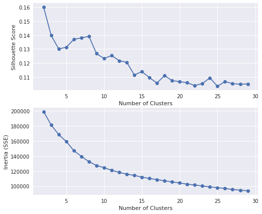

```python
optimal_clusters(pca_transform_main)
```

Let us consider the Number of clusters = 7 since it is a point where SSE is low and silhouette score is high

```python
kmeans_main = KMeans(n_clusters = 7, random_state=42)
preds_main = kmeans_main.fit_predict(pca_transform_main)
```

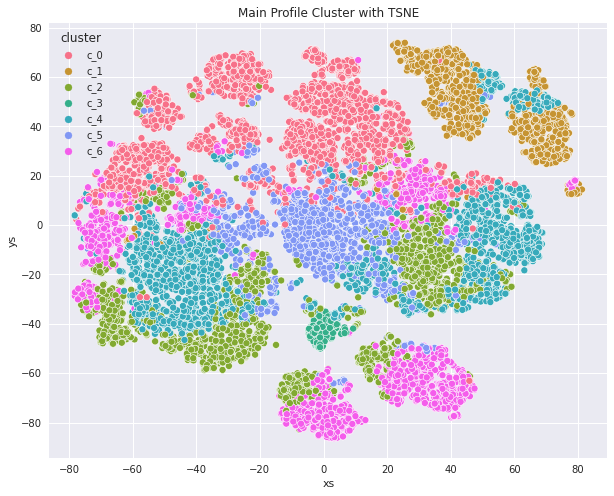

```python
tsne = TSNE(random_state=42).fit_transform(pca_transform_main)
tsne_df = pd.DataFrame(tsne, columns=['xs', 'ys'])
tsne_df['cluster'] = ['c_' + str(i) for i in preds_main]

# Plot tsne
f,ax = plt.subplots(figsize=(10,8))
sns.scatterplot('xs','ys', hue='cluster', data=tsne_df, ax=ax, hue_order=['c_' + str(i) for i in range(0,7)])
ax.set_title("Main Profile Cluster with TSNE")
# Save figure
f.savefig('main_tsne.png', dpi = 300)
```

The figure helps us to visualize the 7 possible clusters. But this seems too cluttered and all over the place. Let us try to improve it by employing HDBSCAN

```python
session = sagemaker.Session() # Obtain the current SageMaker session
# Obtain IAM role
role = get_execution_role()
print(role)
```

```
arn:aws:iam::226478391390:role/service-role/AmazonSageMaker-ExecutionRole-20220123T104482
```

```python
N_COMPONENTS = scaled_data.shape[1] - 1

pca_starbucks = sagemaker.PCA(role=role,
             instance_count=1,
             instance_type='ml.p2.xlarge',
             output_path=output_path, # Defined above
             num_components=N_COMPONENTS,
             sagemaker_session=session)
```

```python
train_data_np = data_scaled.values.astype('float32')
# Convert to RecordSet format
formatted_train_data = pca_starbucks.record_set(train_data_np)
```

```python
# Fit the data
pca_starbucks.fit(formatted_train_data)
```

```
Defaulting to the only supported framework/algorithm version: 1. Ignoring framework/algorithm version: 1.
Defaulting to the only supported framework/algorithm version: 1. Ignoring framework/algorithm version: 1.
```

[output not shown]

[output cut: 17 more lines]

```python
# Get the name of the training job, it's suggested that you copy-paste from a specific job in the AWS console
training_job_name='pca-2022-01-24-17-28-36-260'

# Where the model is saved, by default
model_key = os.path.join(prefix, training_job_name, 'output/model.tar.gz')
print(model_key)

# Download and unzip the model
boto3.resource('s3').Bucket(bucket).download_file(model_key, 'model.tar.gz')

# Unzipping as model_algo-1
os.system('tar -zxvf model.tar.gz')
os.system('unzip model_algo-1')
```

```
training_job_output/pca-2022-01-24-17-28-36-260/output/model.tar.gz
```

```
2304
```

```python
# Loading the unzipped artifacts
pca_model_params = mx.ndarray.load('model_algo-1')
# Model parameters
print(pca_model_params)
```

[output not shown]

[output cut: 25 more lines]

[output not shown]

```python
# Get selected parameters
s=pd.DataFrame(pca_model_params['s'].asnumpy())
v=pd.DataFrame(pca_model_params['v'].asnumpy())
```

Here 'v' and 's' stand for:

v: The makeup of the principal components (Same as ‘components_’ in an sklearn PCA model).

s: The singular values of the components for the PCA transformation. This does not exactly give the % variance from the original feature space, but can give the % variance from the projected feature space.

When we select the top n components to use in a new data model, we'll typically want to include enough components to capture about 80-90% of the original data variance.

Note: The top principal components, with the largest s values, are actually at the end of the s DataFrame. Let's print out the s values for the top n, principal components.

```python
# Looking at top 5 components
n_principal_components = 5
start_idx = N_COMPONENTS - n_principal_components
print(s.iloc[start_idx:, :])
```

```
             0
11  127.810913
12  157.507446
13  179.824448
14  194.913849
15  245.447357
```

```python
def explained_variance(s, n_top_components):
    '''
    Function:
      Calculates the approximate data variance that n_top_components captures.
    Input:
      s: A dataframe of singular values for top components; the top value is in the last row.
      n_top_components: An integer, the number of top components to use.
    Returns:
      The expected data variance covered by the n_top_components.
    '''
    start_index = N_COMPONENTS - n_top_components
    # Calculate approximate variance
    exp_variance = np.square(s.iloc[start_index:,:]).sum()/np.square(s).sum()
    return exp_variance[0]
```

```python
'''
Test to determine the n_top_components
Aim for a minimum of 85% in variance
'''
n_top_components = 10
# Calculate the explained variance
exp_variance = explained_variance(s, n_top_components)
print('Explained variance: ', exp_variance)
```

```
Explained variance:  0.9300544
```

```python
import matplotlib.pyplot as plt
import seaborn as sns

def display_component(v, features_list, component_num, n_weights=10):
    '''
    Function:
      Displays feature-level makeup of the first component in the form of a bar chart
    Input:
      v: The makeup of the principal components
      features_list: List of features/columns in data
      component_num: An integer, the number of components.
      n_weights: Number of features.
    Returns:
      A bar chart.
    '''
    # Obtain index of component
    row_idx = N_COMPONENTS-component_num

    # Obtain the list of weights from a row in v, dataframe
    v_1_row = v.iloc[:, row_idx]
    v_1 = np.squeeze(v_1_row.values)

    # Match weights to features in dataframe, using list comprehension
    comps = pd.DataFrame(list(zip(v_1, features_list)),
                         columns=['weights', 'features'])

    # Sort by the largest n_weights, weights can be neg/pos so sort by magnitude
    comps['abs_weights']=comps['weights'].apply(lambda x: np.abs(x))
    sorted_weight_data = comps.sort_values('abs_weights', ascending=False).head(n_weights)

    # Display using seaborn
    ax=plt.subplots(figsize=(20,8))
    ax=sns.barplot(data=sorted_weight_data,
                   x="weights",
                   y="features",
                   palette="Blues_d")
    ax.set_title("PCA Component Makeup, Component #" + str(component_num))
    plt.show()
```

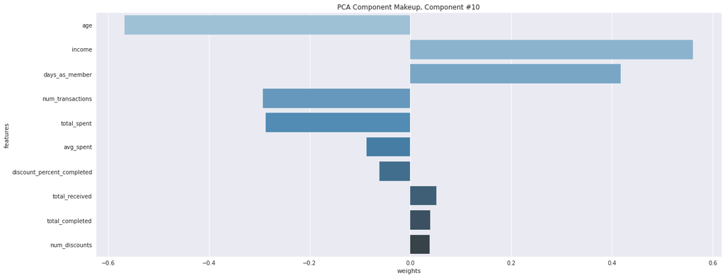

```python
num = 10
display_component(v, customer_transactions.columns.values, component_num=num, n_weights=10)
```

```python
pca_predictor = pca_starbucks.deploy(initial_instance_count=1,
                              instance_type='ml.p2.xlarge')
```

```
Defaulting to the only supported framework/algorithm version: 1. Ignoring framework/algorithm version: 1.
```

```
-------!
```

The model is now deployed and we can use it to make "predictions". Pass in the training data into the deployed endpoint to create principal components for each data point.

```python
train_pca = pca_predictor.predict(train_data_np)
```

```python
def create_transformed_df(train_pca, data_scaled, n_top_components):
    '''
    Function:
      Creates a dataframe of data points with component features.
    Input:
      train_pca: A list of pca training data, returned by a PCA model.
      data_scaled: A dataframe of normalized, original features.
      n_top_components: An integer, the number of top components to use.
      return: A dataframe, with n_top_component values as columns.
    Returns:
      A DataFrame of data points with component features
     '''
    # Result DataFrame
    data_transformed=pd.DataFrame()

    # For every new data points append the component values to the dataframe
    for data in train_pca:
        # Obtain component values for each data point
        components=data.label['projection'].float32_tensor.values
        data_transformed = data_transformed.append([list(components)])
    data_transformed.index = data_scaled.index

    # Retain only the top n components
    start_idx = N_COMPONENTS - n_top_components
    data_transformed = data_transformed.iloc[:,start_idx:]

    # Reverse columns
    return data_transformed.iloc[:, ::-1]
```

```python
# Specify top n
top_n = 10
data_transformed = create_transformed_df(train_pca, data_scaled, n_top_components=top_n)

# Add descriptive columns/legend
PCA_list=['c_1', 'c_2', 'c_3', 'c_4', 'c_5','c_6', 'c_7', 'c_8', 'c_9', 'c_10']
data_transformed.columns=PCA_list
data_transformed.head()
```

|  | c_1 | c_2 | c_3 | c_4 | c_5 | c_6 | c_7 | c_8 | c_9 | c_10 |
| --- | --- | --- | --- | --- | --- | --- | --- | --- | --- | --- |
| 0 | 2.454468 | 0.500698 | 4.245850 | -0.477935 | 0.048781 | 0.369806 | 0.069349 | 1.673448 | 0.281755 | 1.069173 |
| 1 | -1.548740 | 3.202874 | 2.238256 | 0.314186 | -0.969619 | 0.868507 | 0.195821 | 0.338508 | -0.087950 | 0.187228 |
| 2 | 0.697078 | -1.012002 | 0.577255 | 0.978224 | -0.398154 | -0.239852 | 0.559175 | -0.013631 | -1.200845 | -0.367026 |
| 3 | -2.277015 | 1.141493 | -1.740282 | 1.581004 | -1.830155 | -0.170661 | 0.170049 | -0.988605 | -1.594432 | -0.159415 |
| 4 | 2.125264 | -2.533382 | 0.682931 | -0.829123 | -1.247389 | -0.331514 | 0.074033 | -0.844839 | -0.994296 | -0.362003 |

```python
data_transformed.to_csv('pca_scores.csv')
```

```python
# Upload to checkpoint
s3 = boto3.resource('s3')
s3.meta.client.upload_file('pca_scores.csv', bucket, 'Checkpoints/pca_scores.csv')
```

```python
# Delete the predictor endpoint
session.delete_endpoint(pca_predictor.endpoint)
```

```
The endpoint attribute has been renamed in sagemaker>=2.
See: https://sagemaker.readthedocs.io/en/stable/v2.html for details.
```

```python
def plot_percentage(ax, feature):
    '''
    Function:
      Displays percentage of category in the overall data set.
    Input:
      ax: Axes Seaborn object
      feature: Name of the feature/column in the dataset
    Returns:
      None
    '''
    total = len(feature)
    for p in ax.patches:
        percentage = '{:.1f}%'.format(100 * p.get_height()/total)
        x = p.get_x() + p.get_width() / 2 - 0.05
        y = p.get_y() + p.get_height()
        ax.annotate(percentage, (x, y), size = 12)
    plt.show()

def plot_category_variable(data, column):
    '''
    Function:
      Displays plot of categorical variables
    Input:
        column: Name of the column to be displayed
        data: Dataset/DataFrame
    Returns:
        None
    '''

    plt.figure(figsize=(8, 6))
    ax = sns.countplot(x=column, data=data)
    ax.set_xticklabels(ax.get_xticklabels(), rotation=90)
    plt.suptitle('Frequency of ' + column)

    plot_percentage(ax, data[column])
```

## HDBSCAN

The HDBSCAN model is first fit with just the scaled data.

```python
 plot_kwds = {'alpha' : 0.25, 's' : 80, 'linewidths':0}
```

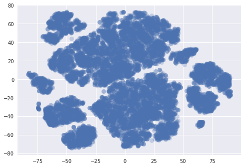

```python
projection = TSNE().fit_transform(scaled_data)
plt.scatter(*projection.T, **plot_kwds)
```

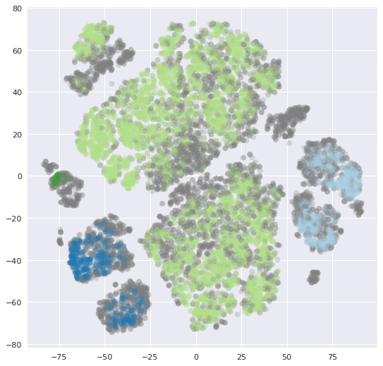

```python
clusterer = hdbscan.HDBSCAN(min_cluster_size=50, min_samples=20).fit(scaled_data)

plt.figure(figsize=(8, 8), dpi=80)
color_palette = sns.color_palette('Paired', 12)
cluster_colors = [color_palette[x] if x >= 0
                  else (0.5, 0.5, 0.5)
                  for x in clusterer.labels_]
cluster_member_colors = [sns.desaturate(x, p) for x, p in
                         zip(cluster_colors, clusterer.probabilities_)]
plt.scatter(*projection.T, s=50, linewidth=0, c=cluster_member_colors, alpha=0.25)
```

The scaled data without the pca produces the above figure/cluster.

Here the black dots represent noise. Since the graph is filled with them, this indicates something is wrong with the fitting of the data.

Lets try again but with the data passed and trained through the PCA

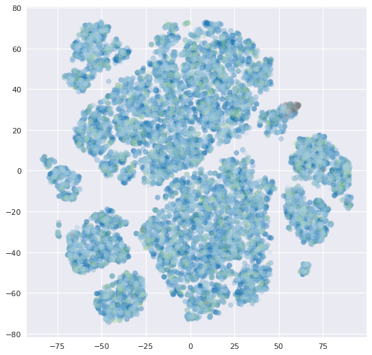

```python
pca = pd.read_csv('pca_scores.csv')
clusterer = hdbscan.HDBSCAN(min_cluster_size=50, min_samples=20).fit(pca)

plt.figure(figsize=(8, 8), dpi=80)
color_palette = sns.color_palette('Paired', 12)
cluster_colors = [color_palette[x] if x >= 0
                  else (0.5, 0.5, 0.5)
                  for x in clusterer.labels_]
cluster_member_colors = [sns.desaturate(x, p) for x, p in
                         zip(cluster_colors, clusterer.probabilities_)]
plt.scatter(*projection.T, s=50, linewidth=0, c=cluster_member_colors, alpha=0.25)
```

Much better. This plot represents about three clusters by the looks of the colours. There is also a bit of noise at the top, but much less than last time.

```python
np.unique(clusterer.labels_) # Three clusters with -1 being the noise
```

```
array([-1,  0,  1,  2])
```

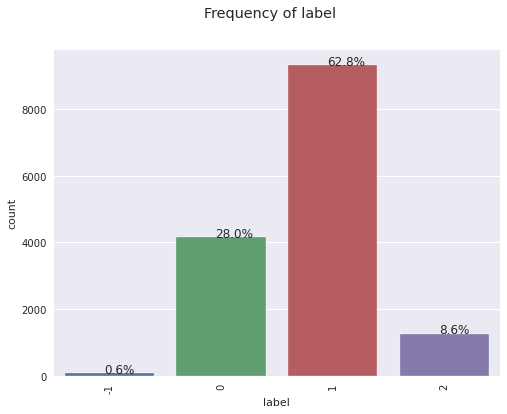

```python
label_pca = clusterer.labels_
label_pca = pd.DataFrame({"label": clusterer.labels_})
# Display plot for each label
plot_category_variable(label_pca, 'label')
```

```python
# Save dataset with a column as cluster label
df_cluster = data_scaled.copy()
df_cluster['labels'] = clusterer.labels_
df_cluster.sample(20)
```

|  | 0 | 1 | 2 | 3 | 4 | 5 | 6 | 7 | 8 | 9 | 10 | 11 | 12 | 13 | 14 | 15 | 16 | labels |
| --- | --- | --- | --- | --- | --- | --- | --- | --- | --- | --- | --- | --- | --- | --- | --- | --- | --- | --- |
| 13752 | -1.115653 | -0.395442 | -0.070042 | 0.591354 | 0.582649 | 0.762232 | 0.556350 | 1.063557 | -1.361495 | 0.587572 | -0.070150 | 0.895062 | 0.346222 | 0.512935 | 0.478540 | -0.023916 | 0.493128 | 0 |
| 11806 | -0.080165 | 0.149335 | 0.270895 | 0.591354 | -0.564313 | 2.854357 | -0.157704 | -0.842540 | 0.027550 | 0.240751 | -0.415542 | -0.069725 | -0.255677 | -0.119121 | 0.478540 | 0.187456 | 1.267558 | 0 |
| 8807 | 0.437578 | -0.455240 | 0.782301 | 0.591354 | 1.729610 | -0.902880 | 0.556350 | 1.063557 | -0.666973 | -0.106070 | 0.620633 | -1.227469 | -1.459474 | -1.383232 | 1.409069 | -0.780684 | 2.041988 | 1 |
| 8075 | 0.264997 | -0.775906 | -1.774727 | -1.719354 | 0.582649 | 2.181633 | -0.633739 | -0.842540 | -1.361495 | -1.493353 | 1.656808 | 1.473934 | 0.797646 | 0.512935 | -0.451989 | -0.587779 | -0.281302 | 1 |
| 970 | -0.425328 | -0.764290 | 1.634643 | 0.591354 | 0.582649 | 2.851972 | 2.698510 | 1.063557 | -1.176289 | -0.452891 | -0.760933 | -0.841554 | -1.459474 | -1.383232 | -0.451989 | -0.816464 | -1.830162 | 1 |
| 12571 | 0.264997 | -0.628055 | -0.070042 | 1.746709 | -1.711274 | -1.208230 | -1.585810 | -0.842540 | -1.037385 | 1.628034 | -1.451716 | -0.455640 | -0.707101 | -0.751176 | -0.451989 | -0.671574 | 0.493128 | 0 |
| 8132 | 0.725214 | 0.501258 | 0.270895 | 0.591354 | 0.582649 | -0.879024 | 0.127918 | -0.842540 | 0.768374 | 0.240751 | 0.275242 | -0.841554 | 0.045273 | -0.119121 | -0.451989 | -0.179348 | 0.493128 | 1 |
| 13903 | 1.990809 | 0.036918 | -0.313568 | 0.591354 | -1.711274 | -1.179603 | -1.585810 | 1.063557 | -0.296561 | 0.934392 | -1.451716 | -0.841554 | -0.707101 | -0.751176 | -0.451989 | -0.413111 | 0.493128 | 0 |
| 2095 | 1.530593 | -0.533277 | 0.782301 | 0.591354 | 0.582649 | 0.342376 | 0.556350 | 1.063557 | -1.500400 | -0.106070 | -0.070150 | -0.262682 | -0.255677 | -0.119121 | 0.478540 | -0.549922 | -0.281302 | 1 |
| 13230 | 1.300484 | -0.767296 | 0.782301 | 0.591354 | -0.564313 | 2.162549 | 2.698510 | -0.842540 | -0.852179 | -0.106070 | -1.106325 | 0.702104 | -1.459474 | -1.383232 | -1.382518 | -0.652953 | -1.055732 | 0 |
| 2692 | 0.552632 | 0.556282 | 0.782301 | -0.564000 | -0.564313 | 0.235027 | -0.871757 | 1.063557 | 2.018514 | -0.799711 | 0.620633 | -0.455640 | 0.797646 | 0.512935 | -0.451989 | 0.222774 | -1.055732 | 1 |
| 6407 | -0.712963 | 0.162189 | -0.751916 | 1.746709 | -1.711274 | -0.401915 | -1.585810 | -0.842540 | 0.120153 | 3.708958 | -1.451716 | 1.280976 | 1.550019 | 1.777046 | 0.478540 | 1.163674 | 1.267558 | 1 |
| 10485 | -1.633396 | -0.804539 | 0.782301 | 0.591354 | 0.582649 | -0.635698 | 0.556350 | -0.842540 | -1.546701 | -0.106070 | -0.070150 | -0.455640 | -0.857575 | -0.751176 | 0.478540 | -0.804845 | -1.055732 | 2 |
| 1301 | -0.137692 | 0.666696 | -0.751916 | 0.591354 | -1.711274 | 0.287509 | -1.585810 | 1.063557 | 2.250022 | 1.974855 | -1.451716 | 0.316190 | 0.346222 | 0.512935 | 0.478540 | 1.110581 | 0.493128 | 1 |
| 12542 | -0.425328 | -0.775906 | 1.293706 | 1.746709 | -1.711274 | -0.425770 | -1.585810 | -0.842540 | -1.546701 | 0.240751 | -1.451716 | -0.841554 | -1.459474 | -1.383232 | 1.409069 | -0.822312 | 1.267558 | 0 |
| 4280 | -0.943072 | -0.268220 | 0.270895 | 0.591354 | -0.564313 | -0.938663 | 0.556350 | 1.063557 | -0.805877 | 0.240751 | -0.760933 | -0.648597 | 0.045273 | -0.119121 | -0.451989 | -0.483286 | -0.281302 | 1 |
| 1111 | -1.863505 | -0.326069 | -0.070042 | -0.564000 | -0.564313 | -0.759747 | -0.157704 | -0.842540 | 0.027550 | -0.452891 | -0.415542 | 1.859848 | 0.546855 | -0.119121 | -1.382518 | 0.470387 | -1.055732 | 1 |
| 7106 | 0.955322 | 0.085828 | -0.070042 | 0.591354 | 0.582649 | -0.754976 | 0.127918 | -0.842540 | 0.166454 | 0.587572 | 0.275242 | -1.227469 | -0.857575 | -0.751176 | 0.478540 | -0.644489 | 1.267558 | 1 |
| 5354 | -0.655436 | -0.735657 | 0.782301 | 1.746709 | -0.564313 | -1.079410 | 2.698510 | -0.842540 | 0.444263 | 0.587572 | -1.106325 | -0.455640 | -1.459474 | -1.383232 | 0.478540 | -0.752829 | 0.493128 | 1 |
| 1056 | -1.230707 | 0.056244 | -0.070042 | -0.564000 | 0.582649 | -1.239242 | -0.157704 | 1.063557 | -0.065053 | -0.452891 | 0.620633 | 0.123232 | 0.346222 | 0.512935 | 0.478540 | 0.218003 | 1.267558 | 1 |

```python
# Upload final csv to S3
df_cluster.to_csv('final_segmentation.csv')
s3 = boto3.resource('s3')
s3.meta.client.upload_file('final_segmentation.csv', bucket, 'Checkpoints/final.csv')
```

```python
customer_transactions['cluster'] = df_cluster['labels']
df_cluster.columns = customer_transactions.columns
```

## Result visualizations

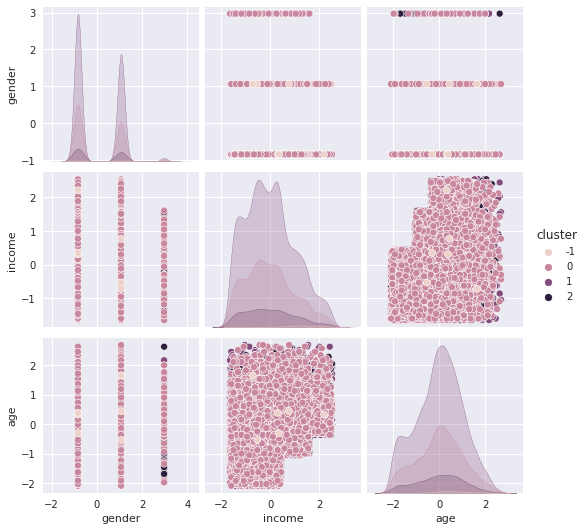

```python
personal_details = ['gender', 'income', 'age', 'cluster']
sns.pairplot(df_cluster[personal_details], hue='cluster');
```

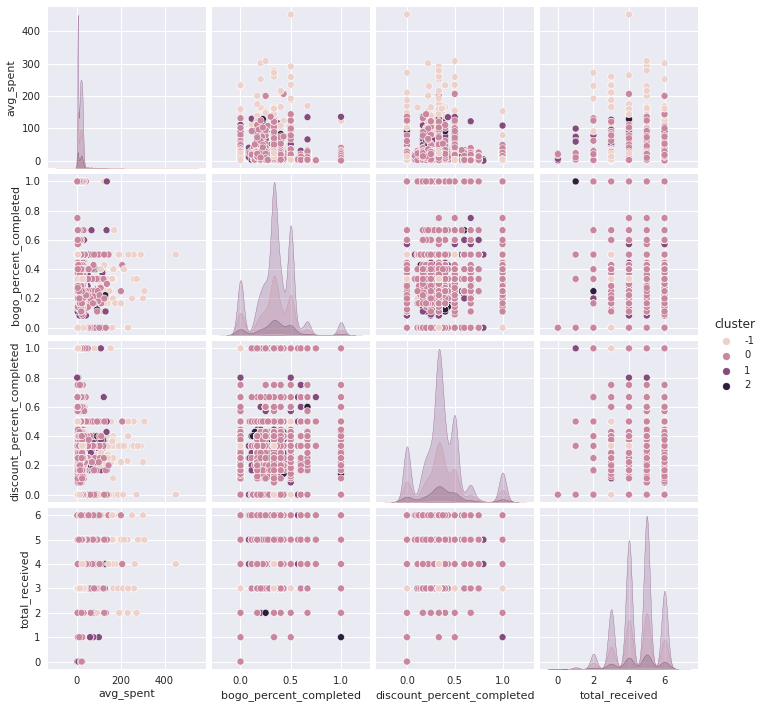

```python
behavioral_attributes = ['cluster', 'avg_spent', 'bogo_percent_completed', 'discount_percent_completed', 'total_received']
sns.pairplot(customer_transactions[behavioral_attributes], hue = 'cluster');
```

```python
df_cluster.head()
```

|  | age | avg_spent | bogo_percent_completed | completed_bogo | completed_discount | days_as_member | discount_percent_completed | gender | income | num_bogos | num_discounts | num_transactions | percent_completed | total_completed | total_received | total_spent | total_viewed | cluster |
| --- | --- | --- | --- | --- | --- | --- | --- | --- | --- | --- | --- | --- | --- | --- | --- | --- | --- | --- |
| 0 | 0.034889 | 0.638206 | 0.782301 | -0.564000 | -1.711274 | -0.349433 | -1.585810 | 1.063557 | 2.157419 | -0.799711 | -1.451716 | -1.034512 | -1.459474 | -0.751176 | -2.313047 | -0.307925 | -2.604592 | -1 |
| 1 | 1.185430 | 0.459859 | -0.070042 | 1.746709 | -1.711274 | -0.189601 | -1.585810 | 1.063557 | 1.601801 | 1.628034 | -1.451716 | -0.262682 | 0.797646 | 0.512935 | -0.451989 | 0.325036 | 0.493128 | -1 |
| 2 | 0.782741 | 0.245295 | -0.070042 | -0.564000 | 0.582649 | -1.029314 | 0.127918 | -0.842540 | 0.212756 | -0.452891 | 0.275242 | -1.034512 | 0.045273 | -0.119121 | -0.451989 | -0.456278 | -0.281302 | -1 |
| 3 | 0.610160 | -0.188782 | -0.844899 | 0.591354 | 0.582649 | -0.848012 | -0.157704 | -0.842540 | -0.574370 | 2.321675 | 0.620633 | -1.034512 | 1.048437 | 1.777046 | 1.409069 | -0.620174 | 2.041988 | -1 |
| 4 | 0.207470 | -0.692454 | -1.774727 | -1.719354 | 0.582649 | -0.633313 | 0.127918 | -0.842540 | -0.666973 | -1.493353 | 0.275242 | -0.841554 | -0.456309 | -0.751176 | -1.382518 | -0.780299 | -1.055732 | -1 |

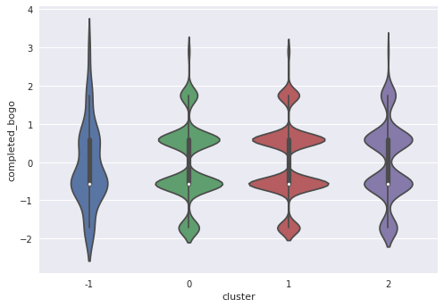

```python
ax = sns.violinplot(x="cluster", y="completed_bogo", data=df_cluster)
```

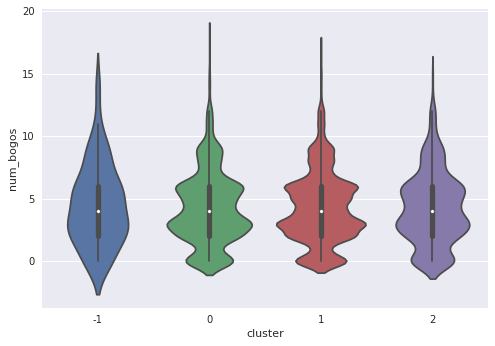

```python
ax = sns.violinplot(x="cluster", y="num_bogos", data=customer_transactions)
```

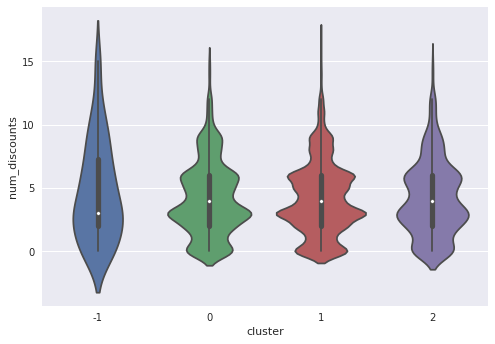

```python
ax = sns.violinplot(x="cluster", y="num_discounts", data=customer_transactions)
```